# Caso de estudio: Análisis de datos Bellabeat

Gabriel Ruviño

2026-07-13

# 1 Introducción

Bellabeat es una empresa dedicada al desarrollo de dispositivos inteligentes orientados al bienestar y salud de las personas. El objetivo de este análisis es explorar los datos recopilados desde dispositivos Fitbit para comprender los hábitos de actividad física y sueño de los usuarios, identificar patrones relevantes y generar recomendaciones que pueden apoyar futuras decisiones de negocio.

# 2 Pregunta de negocio

¿Cómo pueden los datos de actividad física y sueño ayudar a Bellabeat a comprender mejor el comportamiento de sus usuarios y mejorar la experiencia ofrecida por sus productos?

# 3 Preparación de los datos

Los datos utilizados corresponden al conjunto de datos públicos Fitbit Fitness Tracker Data.

Durante esta etapa se realizó:

- Importación de archivos CSV.
- Revisión de la estructura de los datos.
- Conversión de formatos de fecha.
- Identificaicón de valores faltantes.
- Eliminaciónde registros duplicados.
- Creación de nuevas variables para facilitar el análisis.

# 4 Calidad de los datos

## 4.1 dailyActivity

- Registros: 457
- Usuarios: 35
- Valores faltantes: 0
- Duplicados: 0

## 4.2 minuteSleep

- Registros originales: 198559
- Usuarios: 23
- Valores faltantes: 0
- Duplicados: 525

## 4.3 Hallazgo 1: Actividad según el día de la semana

El promedio de pasos diarios presenta variaciones entre los distintos días de la semana.

Se observa una mayor actividad durante los miércoles, mientras que los martes registran el promedio más bajo.

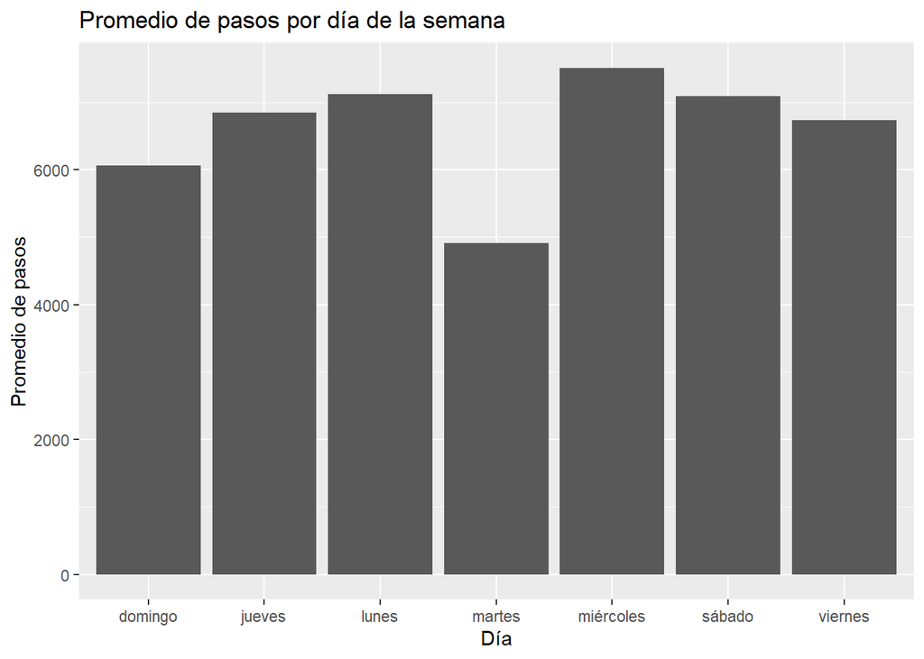

```r
activity %>%
  group_by(day_of_week) %>%
  summarise(promedio_pasos = mean(TotalSteps)) %>%
  ggplot(aes(x = day_of_week, y = promedio_pasos)) +
  geom_col() +
  labs(
    title = "Promedio de pasos por día de la semana",
    x = "Día",
    y = "Promedio de pasos"
  )
```

## 4.4 Hallazgo 2: Pasos y calorías

Se identificó una correlación positiva moderada (r= 0.58) entre la cantidad de pasos diarios y las calorías quemadas.

En términos generales, un mayor número de pasos se asocia con un mayor gasto calórico, aunque existen algunos valores atípicos.

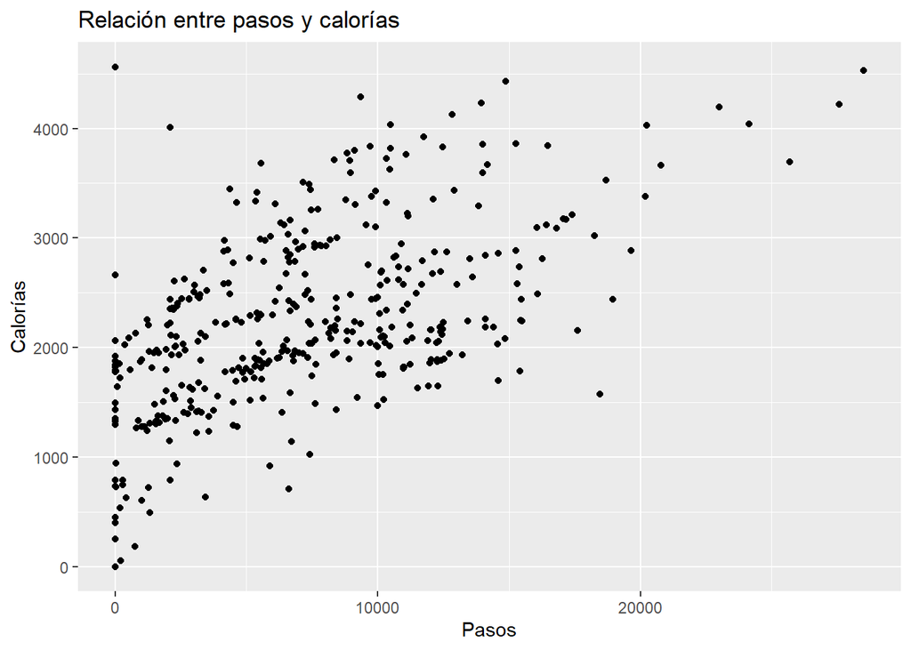

```r
ggplot(activity, aes(x = TotalSteps, y = Calories)) +
  geom_point() +
  labs(
    title = "Relación entre pasos y calorías",
    x = "Pasos",
    y = "Calorías"
  )
```

## Hallazgo 3: Tiempo sedentario

Los usuarios presentan una elevada cantidad de minutos sedentarios durante el día.

También se observaron registros extremos cercanos a las 24 horas de sedentarismo, los cuales podrían corresponder a dispositivos sin uso o registros que requieren revisión.

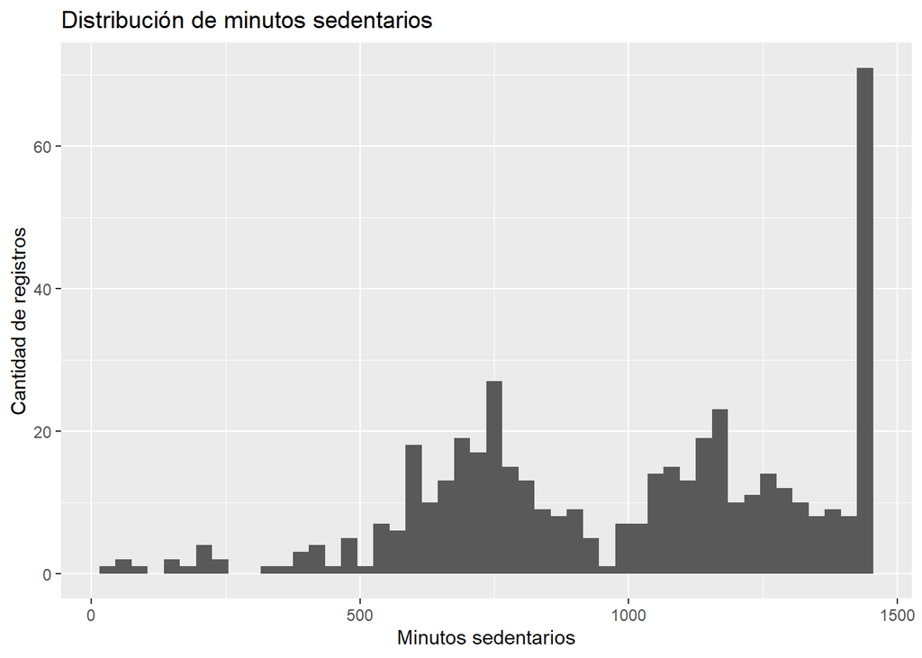

```r
ggplot(activity, aes(x = SedentaryMinutes)) +
  geom_histogram(binwidth = 30) +
  labs(
    title = "Distribución de minutos sedentarios",
    x = "Minutos sedentarios",
    y = "Cantidad de registros"
  )
```

## 4.5 Hallazgo 4: Sueño

Los usuarios registran un promedio de 424 minutos de sueño por noche ( aproximadamente 7,1 horas)

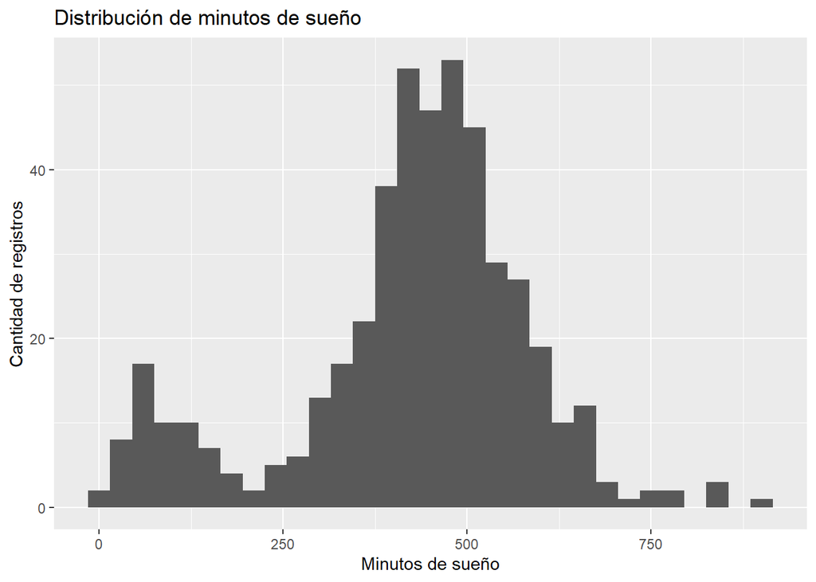

```r
ggplot(sleep_daily, aes(x = minutos_sueno)) +
  geom_histogram(binwidth = 30) +
  labs(
    title = "Distribución de minutos de sueño",
    x = "Minutos de sueño",
    y = "Cantidad de registros"
  )
```

## 4.6 Hallazgo 5: Relación entre sueño y actividad

Al unir la información de actividad física y sueño se obtuvo una correlación de -0,17.

Este resultado indica que la duración del sueño, por si sola, no presenta una relación signficativa con la cantidad de pasos diarios registrados.

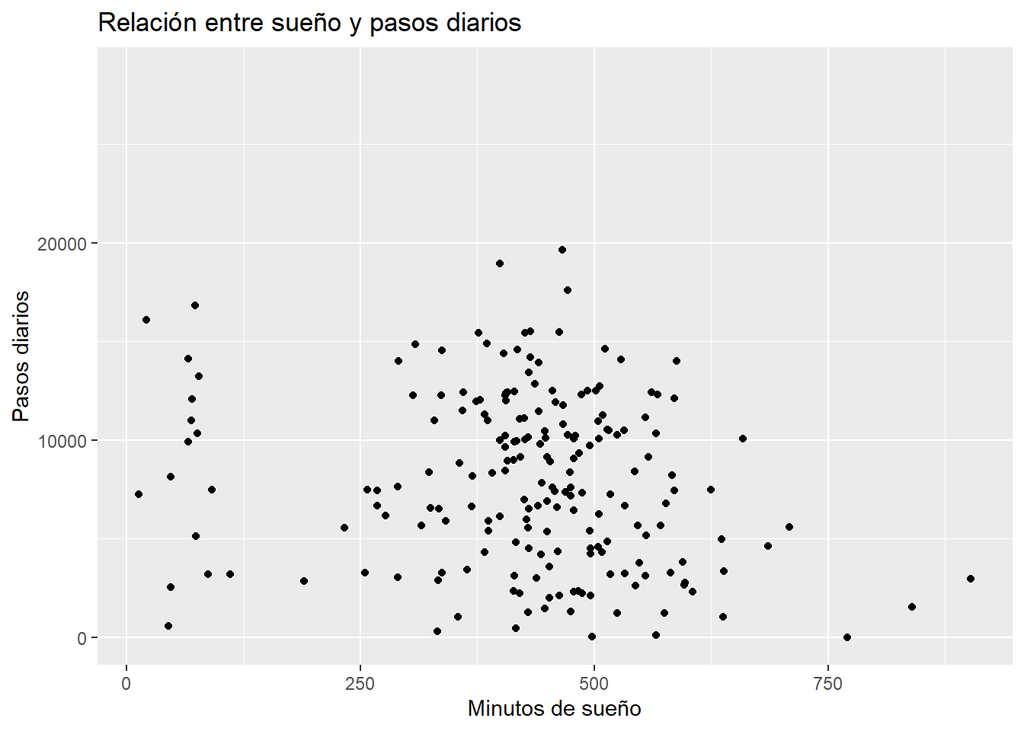

```r
ggplot(activity_sleep,
       aes(x = minutos_sueno,
           y = TotalSteps)) +
  geom_point() +
  labs(
    title = "Relación entre sueño y pasos diarios",
    x = "Minutos de sueño",
    y = "Pasos diarios"
  )
```

# 5 Recomendaciones

A partir del análisis realizado se proponen las siguientes recomendacioens a Bellabeat:

- Incentivar la actividad física durante los días donde se observa menor movimiento.
- Implementar recordatorios personalizados para reducir el tiempo sedentario.
- Promover hábitos de sueño saludables mediante funciones de seguimiento y recordatorios.
- Integrar información de actividad física, sueño y otras métricas (como frecuencia cardíaca) para entregar recomendaciones personalizadas.

# 6 Conclusión

El análisis permitió identificar patrones relevantes en la actividad física y el sueño de los usuarios.

Si bien existe una relación moderada entre pasos diarios y calorías quemadas, no se encontró evidencia de una relación positiva entre la duración del sueño y la cantidad de pasos diarios.

Los resultados obtenidos pueden servir como base para desarrollar funcionalidades orientadas a fomentar hábitos saludables y mejorar la experiencia de los usuarios de Bellabeat.